# ST

Marta Venegas Pardo

6/2/2022

```r
knitr::opts_chunk$set(echo = FALSE , warning = FALSE , message = FALSE )
```

## Modelos estadísticos clásicos

### Modelo de Regresión Lineal General

### Análisis de Series Temporales

Se consideró aplicar un análisis de series temporales debido a la estructura de los datos. ya que este tipo de análisis contempla la estructura temporal de los mismos Como ya se avanzó en el desarrollo teórico, aplicaremos la metodología Box-Jenkis, la cual tiene en cuenta la dependencia existente de los datos, construyendo así un modelo ARIMA.

Trataremos de modelizar el volumen de ventas total según por de la semana. Para construir la serie, primero hemos añadido los días 25 de Diciembre y 1 de Enero con un número de ventas 0, ya que, si no se tomaba esta decisión, la serie ya no estaría definida según la realidad.

#### Creación ST y representación de los datos

Si construimos la serie con los valores actuales, no podremos aplicar transformaciones a la serie, en particuar la transformación de Box-Cox, ya que existen dos valores nulos. Por este motivo, sumamos una constante a todas las observaciones de modo que sean todas positivas.

```
##      p1   p2   p3   p4   p5   p6   p7
## 31                          2049  216
## 32 2418 1955 1648 1798 1783 2005  194
## 33 2140 1518 1698 1615 2040  408  268
## 34 2501 1957 1447 1470 1649 1993  165
## 35 2304 1938 1853 1776 1822 2505  194
## 36 2390 1988 2289 2025 2153 2335  247
## 37 2503 1987 2159 2060  502 3088  249
## 38 2495 2228 2266 1979 1969 2490  241
## 39 2134 2105 2110 1527 2914 2693  174
## 40 2618 2079 2066 2186 2429 2978  178
## 41 2275 2403 2010 2136 2255 2940  220
## 42  410 2972 2502 8021 2343 2942  202
## 43 2258 1835 1677 1821 2410 2611  268
## 44 2391 2495 2396 2538 2445 2568  181
## 45 2433 2185 2317 2307 2367 2631  144
## 46 2396 2010 2073 2130 2491 2960  173
## 47 2407 2013 1876 2218 2252 2575  159
## 48 2143 2181 2274 2018 2667 3050  136
## 49 2499 2252 2242 2019 2358 2899  133
## 50 2372  319 2450 2216 2486 2870  117
## 51 2153 2169 1611 6979 2164 2830  271
## 52 2113 2292 2804 2100   10  350  358
## 53 3014 2780 2647 2023   10 2652  201
## 54 2961 2908   40 2609 2894 2556  171
## 55 2502 2506 2126 2068 2617 2869  109
## 56 2409 2163 1840 2110 2443 3002  128
## 57 2417 2104 2383 2316 2631 2976
```

Después de haber definido los datos como una serie temporal, visualizamos la evolución de la serie en el tiempo.

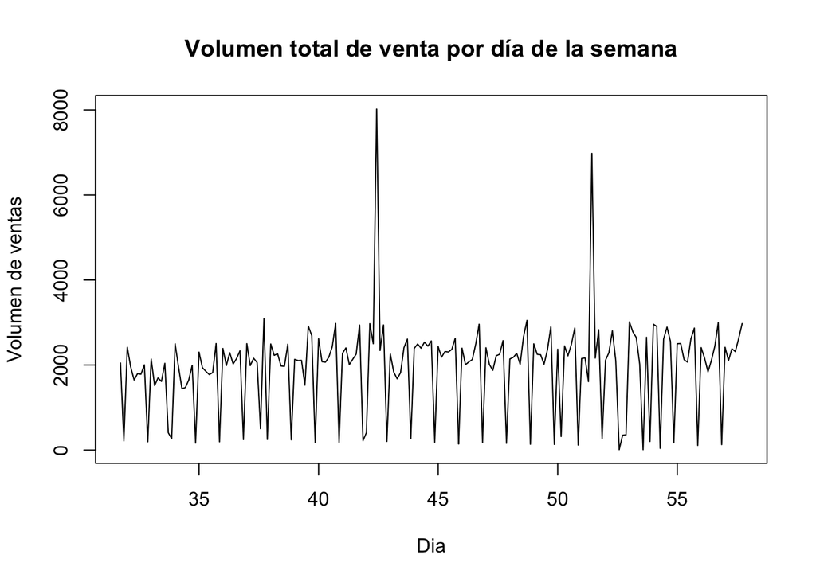

#### Transformación de BoxCox para estabilizar la varianza

Para encontrar una transformación que haga que la varianza sea constante en el tiempo, haremos uso de la familia de transformaciones Box-Cox con ayuda de la librería *TSA*.

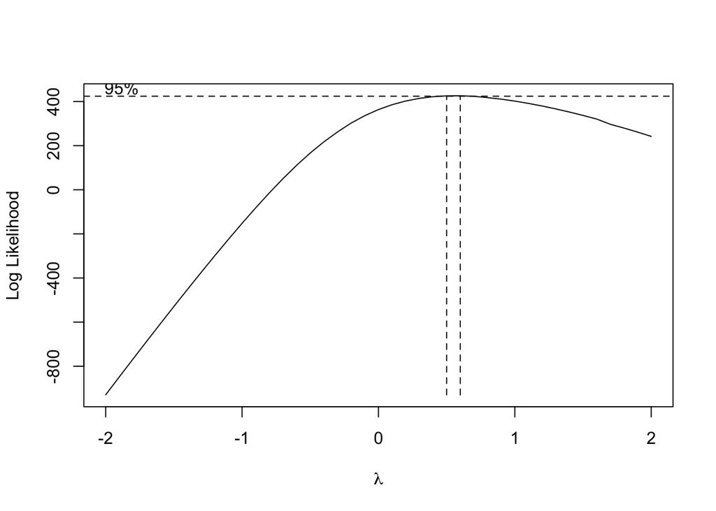

La función *BoxCox.ar* sugiere un óptimo de $\lambda=$. 0.6, con un intervalo de confianza al 95%: (0.5,0.6). Se necesita una transformación sencilla y comprensible, por lo que se ha obtado por tomar como valor de lambda el extremo inferior del intervalo,$\lambda=1/2$.

Transformamos los datos y volvemos a representar la serie.

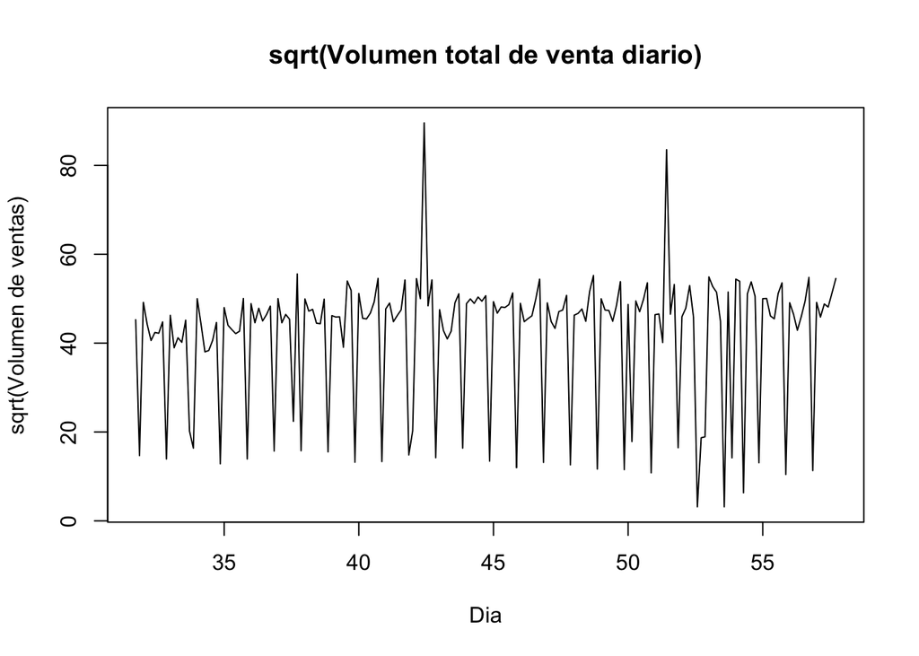

#### Transformaciones para estabilizar la media

Vamos a estudiar si el motivo de la no estacionalidad de los datos en media se debe a que se trata de un proceso integrado. Para ello hacemos uso de la función de correlación simple.

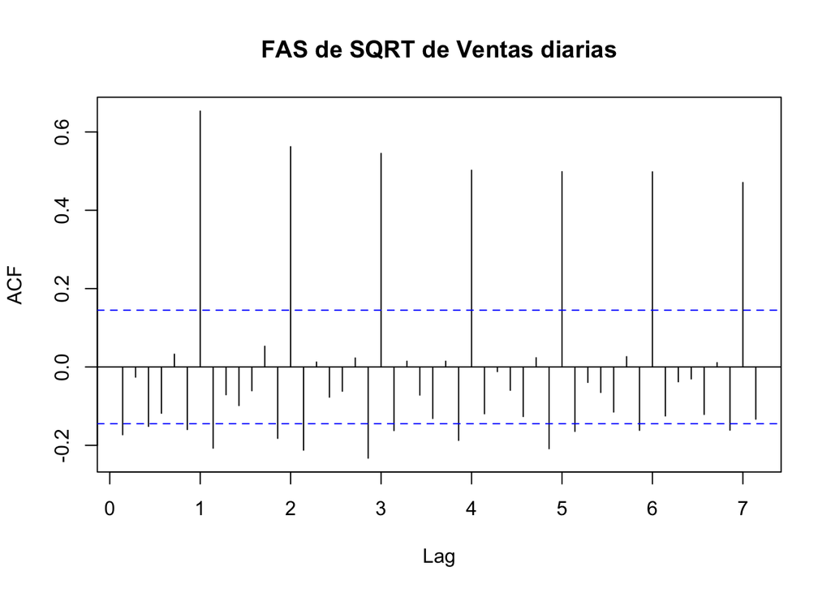

La FAS muestral decrece de lentamente en los retardos estacionales de período 7, indicando que estamos ante un modelo integrado. Debido a esta situación, hacemos una diferencia estacional de la serie.

El siguiente gráfico muestra la FAS tras haber hecho una diferencia estacional de la serie (s=7).

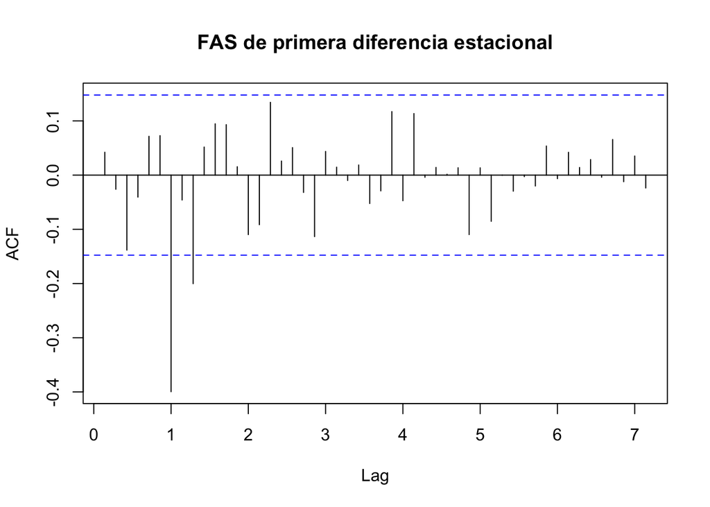

Ahora la función de autocorrelación muestral corresponde a la de un proceso estacionario. Por último, representamos gráficamente la serie diferenciada:

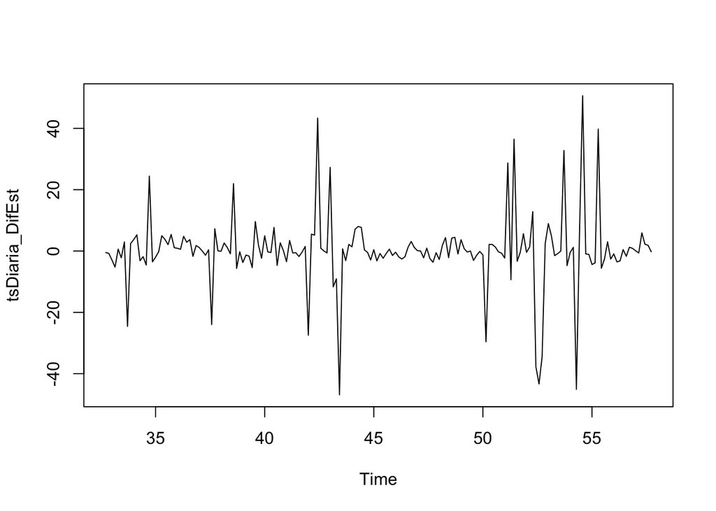

Observamos que la serie no muestra ningún comportamiento en particular, sino que se aprecia aleatoriedad, por lo que se podría pensar, que nos encontramos ante un proceso estacionario. Ahora estamos en condiciones de buscar un modelo estacionario para la serie.

#### Contraste de estacionariedad

Para confirmar la estacionariedad de los datos sugerida con la observación de la gráfica, necesitamos a plicar un test de hipótesis. Aplicamos el test de raíz unitaria de Dikey-Fuller, donde se contrasta la estacionariedad de los datos a través del siguiente contraste de hipótesis:

$$\left\{
\begin{array}{ll}
H_{0}: & \text{El polinomio autoregresivo tiene una raíz unitaria} \\
H_{1}: & \text{Todas las raíces del polinomio autoregresivo son estacionarias}
\end{array}
\right.$$

```
##
##  Augmented Dickey-Fuller Test
##
## data:  tsDiaria_DifEst
## Dickey-Fuller = -5.1008, Lag order = 5, p-value = 0.01
## alternative hypothesis: stationary
```

El p-valor del test= $0.01 < 0.05= \alpha$, y por tanto concluímos que no existen evidencias significativas para asumir que el polinomio autoregresivo tiene alguna raíz unitaria, y por tanto, la serie es estacionaria.

#### Identificación de la estructura ARIMA de la serie

Trataremos de identificar la estructura ARIMA a través de la función de autocorrelación simple (FAC) y de la función de autocorrelación parcial (FAP).

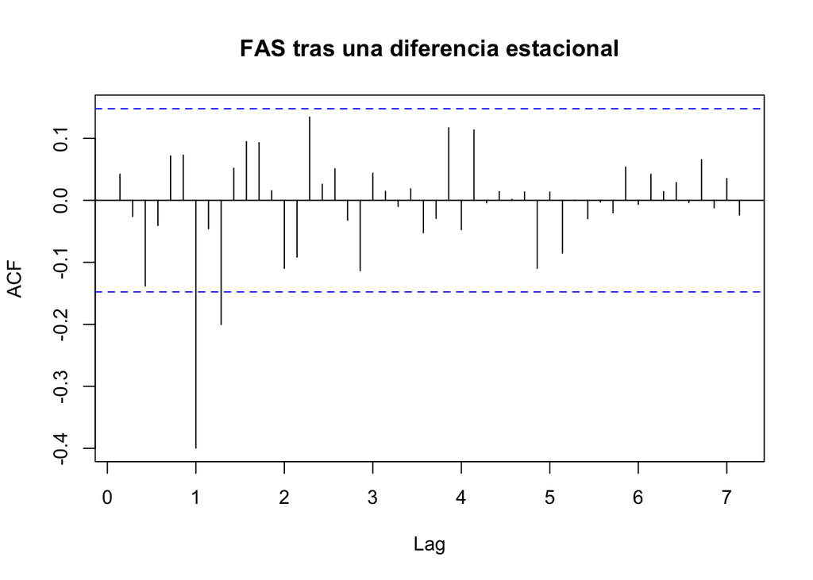

Vamos a comprobar estos supuestos con la FAP.

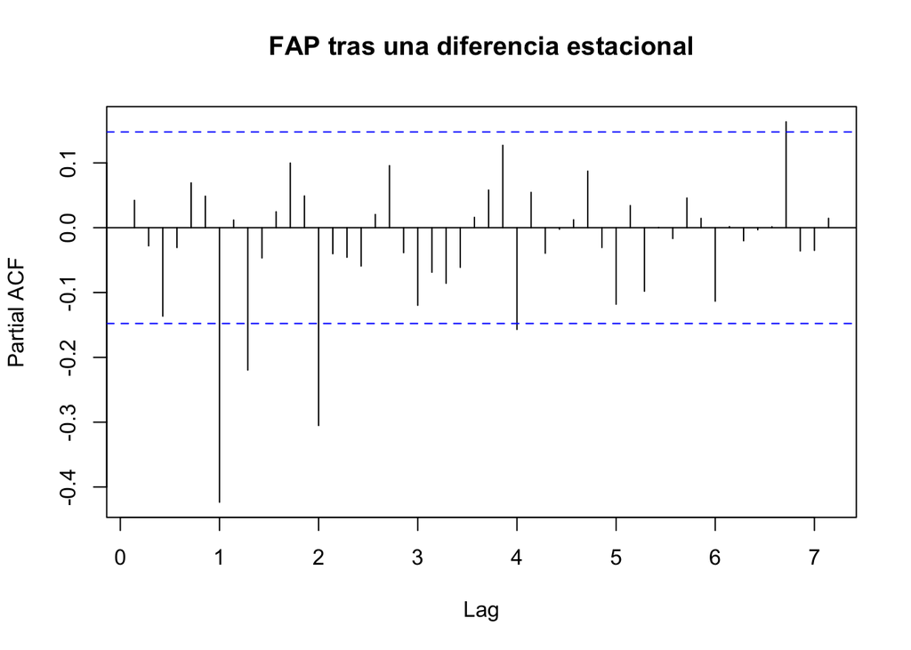

También observamos como hay otras autocorrelaciones significativamente no nulas, pero esto es debido a que se trata de un intervalo de confianza al 95%, por lo que cabe esperar que haya algunas autocorrelaciones fuera de las bandas.

#### Estimación de parámetros y diagnóstico

```r
Ajuste1 = arima( tsDiaria_DifEst ,   # Serie trás una diferencia estacional
                 seasonal = list(order=c(0,0,1),period=7))
Ajuste1
```

```
##
## Call:
## arima(x = tsDiaria_DifEst, seasonal = list(order = c(0, 0, 1), period = 7))
##
## Coefficients:
##          sma1  intercept
##       -1.0000     0.0898
## s.e.   0.0827     0.0871
##
## sigma^2 estimated as 79.04:  log likelihood = -645.71,  aic = 1295.42
```

Trás comprobar si los coeficientes estimados son o no significativamente nulos, procedemos a eliminar la media del modelo, obteniendo así uno donde todos los coeficientes son significativamente no nulos.

```
##                 2.5 %     97.5 %
## sma1      -1.16213365 -0.8378657
## intercept -0.08097887  0.2605421
```

```r
Ajuste1_1 = arima( tsDiaria_DifEst ,   # Serie trás una diferencia estacional
                   order = c(0,0,0),
                 seasonal = list(order=c(0,0,1),period=7), include.mean = FALSE
                 )
Ajuste1_1
```

```
##
## Call:
## arima(x = tsDiaria_DifEst, order = c(0, 0, 0), seasonal = list(order = c(0,
##     0, 1), period = 7), include.mean = FALSE)
##
## Coefficients:
##          sma1
##       -0.9999
## s.e.   0.1009
##
## sigma^2 estimated as 79.52:  log likelihood = -646.24,  aic = 1294.47
```

```
##          2.5 %     97.5 %
## sma1 -1.197648 -0.8021465
```

Para comprobar si el modelo es o no adecuado, comprobamos su valided a través de la diagnosis de los resíduos. Para este ajuste, según el Test de Ljung-Box, no existen evidencias significativas para aceptar la incorrelación de los resíduos: p-valor = $0.002524<0.05 = \alpha$. Además, gráficamente podemos observar que los resíduos no se comportan como un ruido blanco.

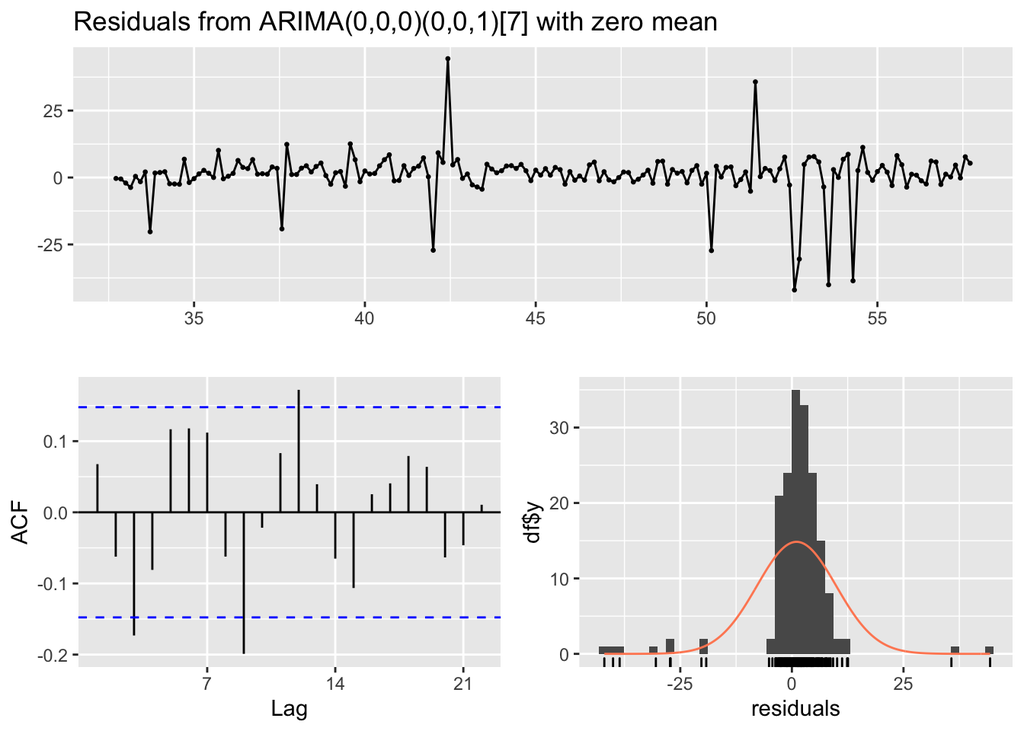

```
##
##  Ljung-Box test
##
## data:  Residuals from ARIMA(0,0,0)(0,0,1)[7] with zero mean
## Q* = 31.855, df = 13, p-value = 0.002524
##
## Model df: 1.   Total lags used: 14
```

Vamos a probar otro modelo, en particular, a través del paquete *forecast* haciendo uso de la función *auto.arima*, que busca un modelo que minimiza el AIC.

```
## Series: tsDiaSemanal_transf
## ARIMA(1,0,0)(2,1,0)[7]
##
## Coefficients:
##          ar1     sar1     sar2
##       0.0709  -0.5180  -0.3068
## s.e.  0.0754   0.0708   0.0694
##
## sigma^2 = 106.2:  log likelihood = -660.08
## AIC=1328.17   AICc=1328.4   BIC=1340.85
```

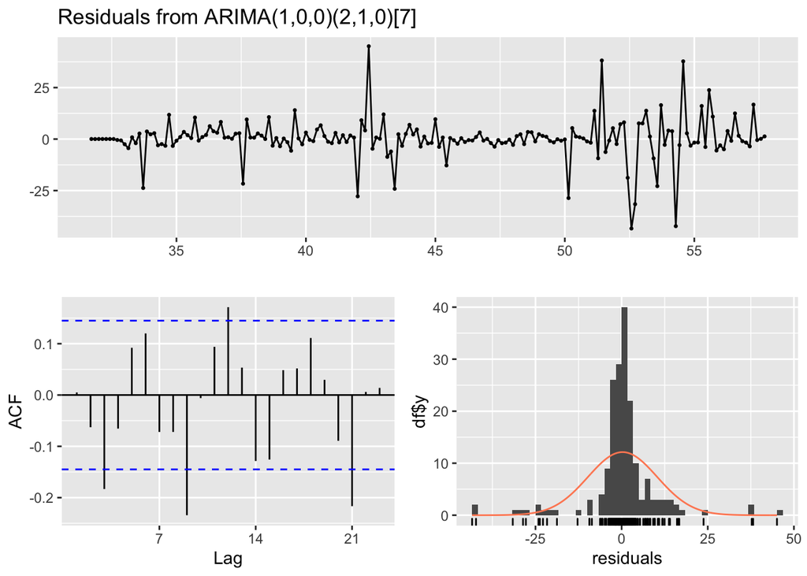

```
##
##  Ljung-Box test
##
## data:  Residuals from ARIMA(1,0,0)(2,1,0)[7]
## Q* = 36.336, df = 11, p-value = 0.0001488
##
## Model df: 3.   Total lags used: 14
```

No encontramos modelo adecuado.